# TPG-Latihan-Pertemuan-9

# Library

```r
library(cluster)
library(factoextra)
library(dplyr)
library(ggplot2)
library(tidyr)
library(scales)
library(readxl)
library(RColorBrewer)
library(readr)
library(clusterCrit)
```

# Import Data

```r
url <- "https://raw.githubusercontent.com/rafiadabhi/STA1342-TPG/main/SESI%20UAS/wine-clustering.csv"
data_wine <- read_csv(url)
data_wine_scaled <- scale(data_wine)
head(data_wine_scaled)
```

```
##        Alcohol  Malic_Acid        Ash Ash_Alcanity  Magnesium Total_Phenols
## [1,] 1.5143408 -0.56066822  0.2313998   -1.1663032 1.90852151     0.8067217
## [2,] 0.2455968 -0.49800856 -0.8256672   -2.4838405 0.01809398     0.5670481
## [3,] 0.1963252  0.02117152  1.1062139   -0.2679823 0.08810981     0.8067217
## [4,] 1.6867914 -0.34583508  0.4865539   -0.8069748 0.92829983     2.4844372
## [5,] 0.2948684  0.22705328  1.8352256    0.4506745 1.27837900     0.8067217
## [6,] 1.4773871 -0.51591132  0.3043010   -1.2860793 0.85828399     1.5576991
##      Flavanoids Nonflavanoid_Phenols Proanthocyanins Color_Intensity        Hue
## [1,]  1.0319081           -0.6577078       1.2214385       0.2510088  0.3611585
## [2,]  0.7315653           -0.8184106      -0.5431887      -0.2924962  0.4049085
## [3,]  1.2121137           -0.4970050       2.1299594       0.2682629  0.3174085
## [4,]  1.4623994           -0.9791134       1.0292513       1.1827317 -0.4263410
## [5,]  0.6614853            0.2261576       0.4002753      -0.3183774  0.3611585
## [6,]  1.3622851           -0.1755994       0.6623487       0.7298108  0.4049085
##          OD280     Proline
## [1,] 1.8427215  1.01015939
## [2,] 1.1103172  0.96252635
## [3,] 0.7863692  1.39122370
## [4,] 1.1807407  2.32800680
## [5,] 0.4483365 -0.03776747
## [6,] 0.3356589  2.23274072
```

# Metode Non Hierarki

## K-Means Clustering

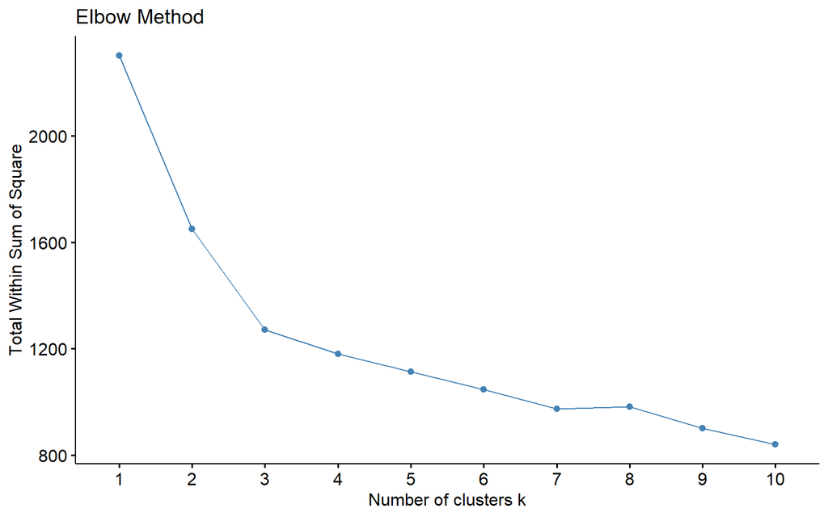

```r
fviz_nbclust(data_wine_scaled, kmeans, method = "wss") +
labs(title = "Elbow Method")
```

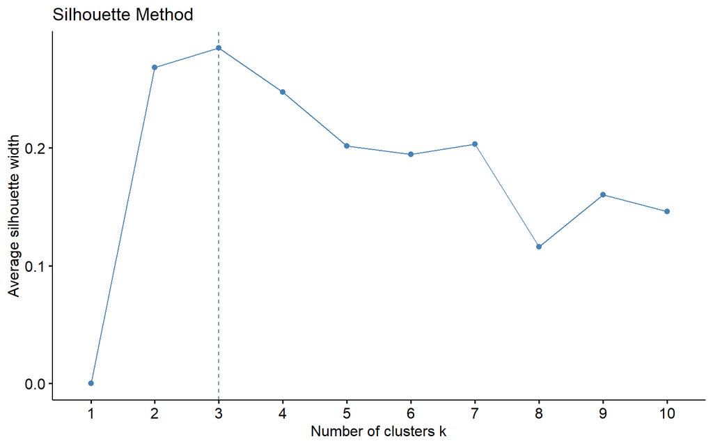

```r
fviz_nbclust(data_wine_scaled, kmeans, method = "silhouette") +
labs(title = "Silhouette Method")
```

Setelah melihat dari pola menggunakan Elbow Method dan Silhoutte, diperoleh pengelompokan yang terbaik itu 3. Selabjutnya dilakukan proses clustering menggunakan fungsi `kmeans()`

Parameter `nstart = 178` digunakan untuk memastikan stabilitas hasil dengan mencoba 178 inisialisasi acak.

```r
set.seed(1106)
kmeans_wine_result <- kmeans(data_wine_scaled, centers = 3, nstart = 178)
kmeans_wine_result
```

```
## K-means clustering with 3 clusters of sizes 51, 62, 65
##
## Cluster means:
##      Alcohol Malic_Acid        Ash Ash_Alcanity   Magnesium Total_Phenols
## 1  0.1644436  0.8690954  0.1863726    0.5228924 -0.07526047   -0.97657548
## 2  0.8328826 -0.3029551  0.3636801   -0.6084749  0.57596208    0.88274724
## 3 -0.9234669 -0.3929331 -0.4931257    0.1701220 -0.49032869   -0.07576891
##    Flavanoids Nonflavanoid_Phenols Proanthocyanins Color_Intensity        Hue
## 1 -1.21182921           0.72402116     -0.77751312       0.9388902 -1.1615122
## 2  0.97506900          -0.56050853      0.57865427       0.1705823  0.4726504
## 3  0.02075402          -0.03343924      0.05810161      -0.8993770  0.4605046
##        OD280    Proline
## 1 -1.2887761 -0.4059428
## 2  0.7770551  1.1220202
## 3  0.2700025 -0.7517257
##
## Clustering vector:
##   [1] 2 2 2 2 2 2 2 2 2 2 2 2 2 2 2 2 2 2 2 2 2 2 2 2 2 2 2 2 2 2 2 2 2 2 2 2 2
##  [38] 2 2 2 2 2 2 2 2 2 2 2 2 2 2 2 2 2 2 2 2 2 2 3 3 1 3 3 3 3 3 3 3 3 3 3 3 2
##  [75] 3 3 3 3 3 3 3 3 3 1 3 3 3 3 3 3 3 3 3 3 3 2 3 3 3 3 3 3 3 3 3 3 3 3 3 3 3
## [112] 3 3 3 3 3 3 3 1 3 3 2 3 3 3 3 3 3 3 3 1 1 1 1 1 1 1 1 1 1 1 1 1 1 1 1 1 1
## [149] 1 1 1 1 1 1 1 1 1 1 1 1 1 1 1 1 1 1 1 1 1 1 1 1 1 1 1 1 1 1
##
## Within cluster sum of squares by cluster:
## [1] 326.3537 385.6983 558.6971
##  (between_SS / total_SS =  44.8 %)
##
## Available components:
##
## [1] "cluster"      "centers"      "totss"        "withinss"     "tot.withinss"
## [6] "betweenss"    "size"         "iter"         "ifault"
```

## Hasil Clustering

```r
table(kmeans_wine_result$cluster)
```

```
##
##  1  2  3
## 51 62 65
```

```r
head(data.frame(Observasi = 1:length(kmeans_wine_result$cluster),
           Cluster = kmeans_wine_result$cluster),10)
```

```
##    Observasi Cluster
## 1          1       2
## 2          2       2
## 3          3       2
## 4          4       2
## 5          5       2
## 6          6       2
## 7          7       2
## 8          8       2
## 9          9       2
## 10        10       2
```

## Komponen Hasil K-Means

```r
names(kmeans_wine_result)
```

```
## [1] "cluster"      "centers"      "totss"        "withinss"     "tot.withinss"
## [6] "betweenss"    "size"         "iter"         "ifault"
```

```r
kmeans_wine_result$cluster
```

```
##   [1] 2 2 2 2 2 2 2 2 2 2 2 2 2 2 2 2 2 2 2 2 2 2 2 2 2 2 2 2 2 2 2 2 2 2 2 2 2
##  [38] 2 2 2 2 2 2 2 2 2 2 2 2 2 2 2 2 2 2 2 2 2 2 3 3 1 3 3 3 3 3 3 3 3 3 3 3 2
##  [75] 3 3 3 3 3 3 3 3 3 1 3 3 3 3 3 3 3 3 3 3 3 2 3 3 3 3 3 3 3 3 3 3 3 3 3 3 3
## [112] 3 3 3 3 3 3 3 1 3 3 2 3 3 3 3 3 3 3 3 1 1 1 1 1 1 1 1 1 1 1 1 1 1 1 1 1 1
## [149] 1 1 1 1 1 1 1 1 1 1 1 1 1 1 1 1 1 1 1 1 1 1 1 1 1 1 1 1 1 1
```

```r
kmeans_wine_result$totss
```

```
## [1] 2301
```

```r
kmeans_wine_result$withinss
```

```
## [1] 326.3537 385.6983 558.6971
```

```r
kmeans_wine_result$tot.withinss
```

```
## [1] 1270.749
```

```r
kmeans_wine_result$betweenss
```

```
## [1] 1030.251
```

```r
kmeans_wine_result$iter
```

```
## [1] 2
```

## Evaluasi Clustering

```r
cluster_km_wine <- kmeans_wine_result$cluster
dist_matrix_wine <- dist(data_wine_scaled, method = "euclidean")

sil <- mean(silhouette(cluster_km_wine, dist_matrix_wine)[, 3])
ch <- intCriteria(traj = as.matrix(data_wine_scaled),
part = cluster_km_wine,
crit = "Calinski_Harabasz")$calinski_harabasz
dunn <- intCriteria(traj = as.matrix(data_wine_scaled),
part = cluster_km_wine,
crit = "Dunn")$dunn

data.frame(Silhouette = sil,
Calinski_Harabasz = ch,
Dunn = dunn)
```

```
##   Silhouette Calinski_Harabasz      Dunn
## 1  0.2848589          70.94001 0.2322567
```

## Karakteristik Clustering

```r
data_wine_clustered <- data.frame(data_wine, cluster = factor(cluster_km_wine))

cluster_wine_summary <- data_wine_clustered %>%
group_by(cluster) %>%
summarise(across(where(is.numeric), mean, .names = "{.col}"))

cluster_wine_summary
```

```
## # A tibble: 3 × 14
##   cluster Alcohol Malic_Acid   Ash Ash_Alcanity Magnesium Total_Phenols
##   <fct>     <dbl>      <dbl> <dbl>        <dbl>     <dbl>         <dbl>
## 1 1          13.1       3.31  2.42         21.2      98.7          1.68
## 2 2          13.7       2.00  2.47         17.5     108.           2.85
## 3 3          12.3       1.90  2.23         20.1      92.7          2.25
## # ℹ 7 more variables: Flavanoids <dbl>, Nonflavanoid_Phenols <dbl>,
## #   Proanthocyanins <dbl>, Color_Intensity <dbl>, Hue <dbl>, OD280 <dbl>,
## #   Proline <dbl>
```

## Visualisasi Clustering

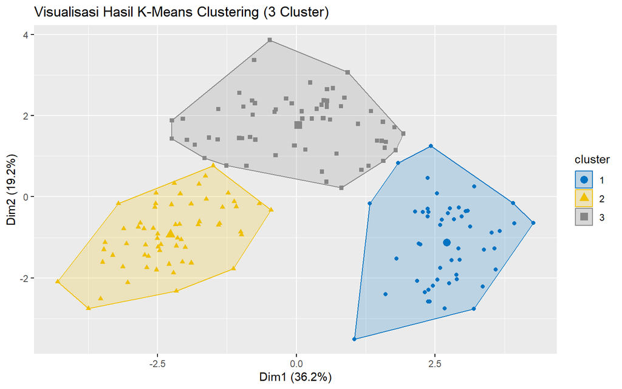

```r
fviz_cluster(kmeans_wine_result, data= data_wine_scaled,
palette = "jco", geom = "point",
main = "Visualisasi Hasil K-Means Clustering (3 Cluster)")
```

```r
heat_data_wine <- cluster_wine_summary %>%
pivot_longer(-cluster, names_to = "Variabel", values_to = "Rata2")
heat_data_wine
```

```
## # A tibble: 39 × 3
##    cluster Variabel              Rata2
##    <fct>   <chr>                 <dbl>
##  1 1       Alcohol              13.1
##  2 1       Malic_Acid            3.31
##  3 1       Ash                   2.42
##  4 1       Ash_Alcanity         21.2
##  5 1       Magnesium            98.7
##  6 1       Total_Phenols         1.68
##  7 1       Flavanoids            0.819
##  8 1       Nonflavanoid_Phenols  0.452
##  9 1       Proanthocyanins       1.15
## 10 1       Color_Intensity       7.23
## # ℹ 29 more rows
```

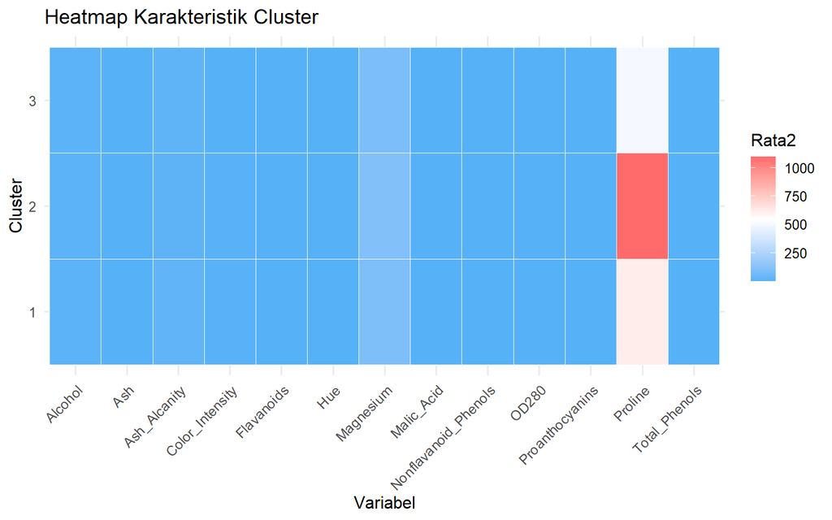

```r
ggplot(heat_data_wine, aes(x = Variabel, y = cluster, fill = Rata2)) +
geom_tile(color = "white") +
scale_fill_gradientn(colors = c("#56B1F7", "white", "#FF6B6B")) +
labs(title = "Heatmap Karakteristik Cluster",
x = "Variabel", y = "Cluster") +
theme_minimal(base_size = 12) +
theme(axis.text.x = element_text(angle = 45, hjust = 1))
```

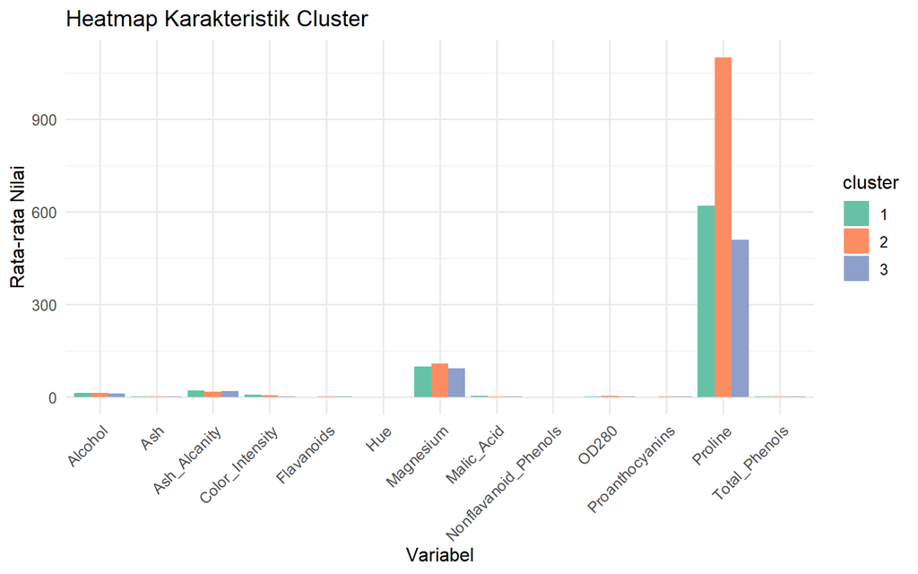

```r
ggplot(heat_data_wine, aes(x = Variabel, y = Rata2, fill = cluster)) +
geom_bar(stat = "identity", position = "dodge") +
scale_fill_brewer(palette = "Set2") +
labs(title = "Heatmap Karakteristik Cluster",
x = "Variabel", y = "Rata-rata Nilai") +
theme_minimal(base_size = 12) +
theme(axis.text.x = element_text(angle = 45, hjust = 1))
```

## Kesimpulan

- **Cluster 1** menggambarkan kelompok wine dengan kadar alkohol sedang tetapi keasaman tinggi (karena Malic Acid tinggi). Rendahnya Flavanoids dan Phenols menandakan kandungan senyawa polifenol antioksidan lebih sedikit, yang sering dikaitkan dengan rasa lebih asam dan ringan. Color Intensity yang tinggi tapi Hue rendah mengindikasikan warna merah tua pekat, khas wine muda dengan karakter asam. ➡️ Secara umum, Cluster 1 dapat diasosiasikan dengan wine yang asam, berwarna pekat, dan kadar alkohol sedang — kemungkinan wine jenis table wine atau young red wine.
- **Cluster 2** mencerminkan wine dengan kualitas kimia terbaik. Kadar alkohol dan phenolic compounds yang tinggi menunjukkan kompleksitas rasa dan aroma yang kuat — biasanya wine yang berkualitas tinggi, matang, dan seimbang. Nilai Hue dan OD280 yang tinggi menandakan warna jernih dan cerah, menunjukkan proses fermentasi dan penyimpanan yang baik. ➡️ Cluster 2 menggambarkan wine dengan karakter kuat, kaya rasa, dan berpotensi memiliki nilai jual tinggi.
- **Cluster 3** menggambarkan wine dengan karakter ringan dan warna pucat. Kadar alkohol dan intensitas warna yang rendah mengindikasikan wine yang ringan, cenderung mudah diminum, dan tidak terlalu kompleks. Nilai Phenols dan Flavanoids yang sedang menunjukkan rasa yang seimbang tapi tidak sekuat Cluster 2. ➡️ Jadi Cluster 3 mewakili wine dengan karakter lembut, ringan, dan mudah diminum, mungkin tipe white wine atau light red wine.